# Explore and Summarize Data by Germanas Latvaitis

# Initial data exploration

```
##        X          fixed.acidity   volatile.acidity  citric.acid
##  Min.   :   1.0   Min.   : 4.60   Min.   :0.1200   Min.   :0.000
##  1st Qu.: 400.5   1st Qu.: 7.10   1st Qu.:0.3900   1st Qu.:0.090
##  Median : 800.0   Median : 7.90   Median :0.5200   Median :0.260
##  Mean   : 800.0   Mean   : 8.32   Mean   :0.5278   Mean   :0.271
##  3rd Qu.:1199.5   3rd Qu.: 9.20   3rd Qu.:0.6400   3rd Qu.:0.420
##  Max.   :1599.0   Max.   :15.90   Max.   :1.5800   Max.   :1.000
##  residual.sugar     chlorides       free.sulfur.dioxide
##  Min.   : 0.900   Min.   :0.01200   Min.   : 1.00
##  1st Qu.: 1.900   1st Qu.:0.07000   1st Qu.: 7.00
##  Median : 2.200   Median :0.07900   Median :14.00
##  Mean   : 2.539   Mean   :0.08747   Mean   :15.87
##  3rd Qu.: 2.600   3rd Qu.:0.09000   3rd Qu.:21.00
##  Max.   :15.500   Max.   :0.61100   Max.   :72.00
##  total.sulfur.dioxide    density             pH          sulphates
##  Min.   :  6.00       Min.   :0.9901   Min.   :2.740   Min.   :0.3300
##  1st Qu.: 22.00       1st Qu.:0.9956   1st Qu.:3.210   1st Qu.:0.5500
##  Median : 38.00       Median :0.9968   Median :3.310   Median :0.6200
##  Mean   : 46.47       Mean   :0.9967   Mean   :3.311   Mean   :0.6581
##  3rd Qu.: 62.00       3rd Qu.:0.9978   3rd Qu.:3.400   3rd Qu.:0.7300
##  Max.   :289.00       Max.   :1.0037   Max.   :4.010   Max.   :2.0000
##     alcohol         quality
##  Min.   : 8.40   Min.   :3.000
##  1st Qu.: 9.50   1st Qu.:5.000
##  Median :10.20   Median :6.000
##  Mean   :10.42   Mean   :5.636
##  3rd Qu.:11.10   3rd Qu.:6.000
##  Max.   :14.90   Max.   :8.000
```

```
## 'data.frame':    1599 obs. of  13 variables:
##  $ X                   : int  1 2 3 4 5 6 7 8 9 10 ...
##  $ fixed.acidity       : num  7.4 7.8 7.8 11.2 7.4 7.4 7.9 7.3 7.8 7.5 ...
##  $ volatile.acidity    : num  0.7 0.88 0.76 0.28 0.7 0.66 0.6 0.65 0.58 0.5 ...
##  $ citric.acid         : num  0 0 0.04 0.56 0 0 0.06 0 0.02 0.36 ...
##  $ residual.sugar      : num  1.9 2.6 2.3 1.9 1.9 1.8 1.6 1.2 2 6.1 ...
##  $ chlorides           : num  0.076 0.098 0.092 0.075 0.076 0.075 0.069 0.065 0.073 0.071 ...
##  $ free.sulfur.dioxide : num  11 25 15 17 11 13 15 15 9 17 ...
##  $ total.sulfur.dioxide: num  34 67 54 60 34 40 59 21 18 102 ...
##  $ density             : num  0.998 0.997 0.997 0.998 0.998 ...
##  $ pH                  : num  3.51 3.2 3.26 3.16 3.51 3.51 3.3 3.39 3.36 3.35 ...
##  $ sulphates           : num  0.56 0.68 0.65 0.58 0.56 0.56 0.46 0.47 0.57 0.8 ...
##  $ alcohol             : num  9.4 9.8 9.8 9.8 9.4 9.4 9.4 10 9.5 10.5 ...
##  $ quality             : int  5 5 5 6 5 5 5 7 7 5 ...
```

# Univariate Plots Section

First I will check the distribution of my featured variable: quality.

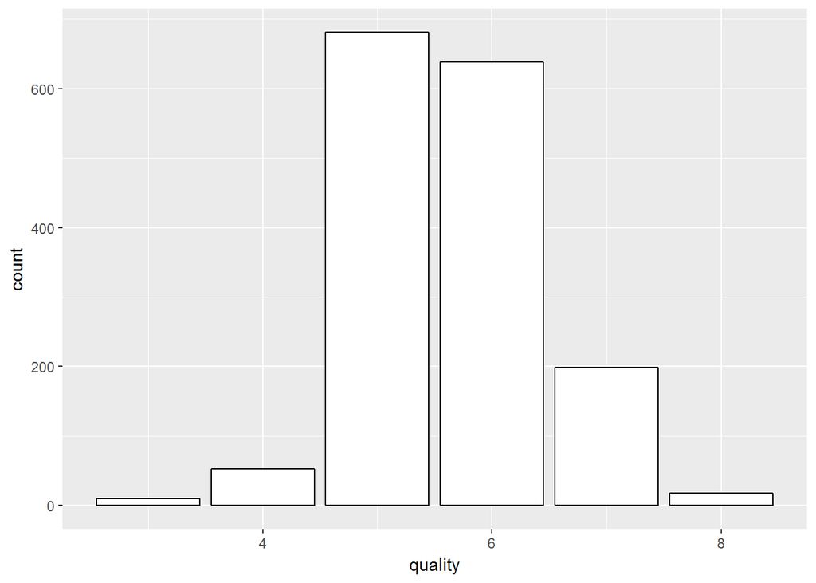

```
##    Min. 1st Qu.  Median    Mean 3rd Qu.    Max.
##   3.000   5.000   6.000   5.636   6.000   8.000
```

In this histogram I can see that most of the values are binned in quality range of 5 - 6. To see the distribution better I will transform the plot using scale_y_log10.

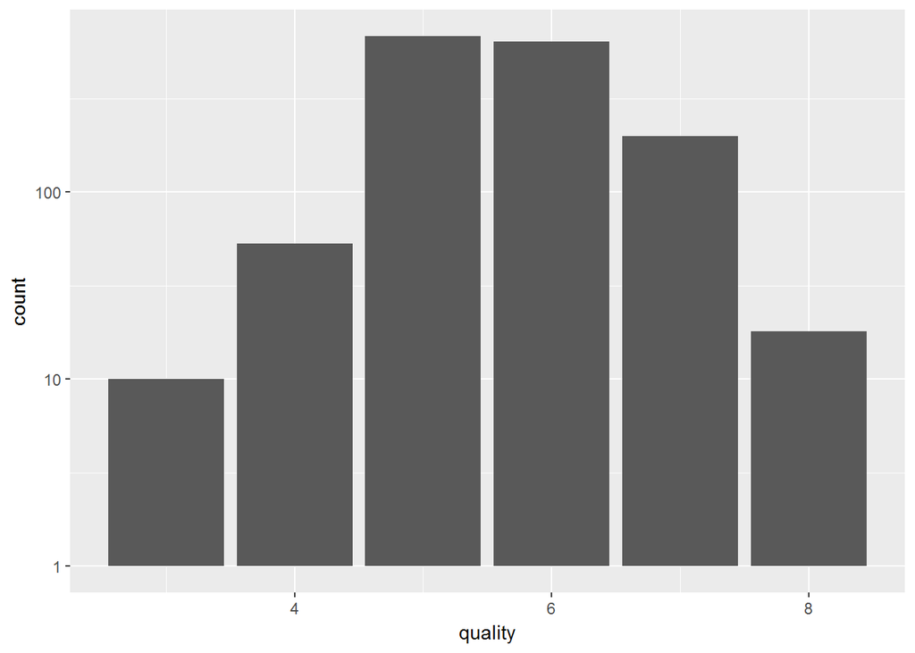

Transforming the plot with log10 shows me a normal distribution.

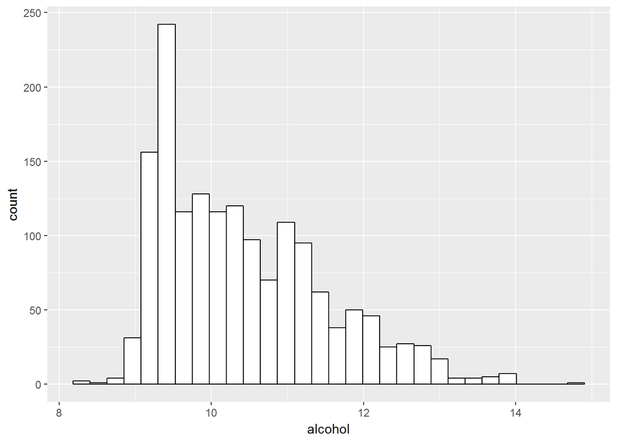

```
##    Min. 1st Qu.  Median    Mean 3rd Qu.    Max.
##    8.40    9.50   10.20   10.42   11.10   14.90
```

With this histogram I wanted to see which alcohol consistensy is the most popular. I can now see that there are some outliers which I will try to adress later.

Now I will draw a histogram of violatile.acidity distribution:

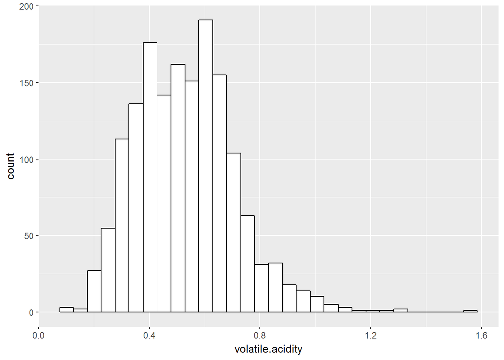

```
##    Min. 1st Qu.  Median    Mean 3rd Qu.    Max.
##  0.1200  0.3900  0.5200  0.5278  0.6400  1.5800
```

According to summary, the 3rd quartile is 0.64 and the max value is 1.58 which tells me that there is a possibility of outlier here.

Finaly I will check the distribution of pH levels

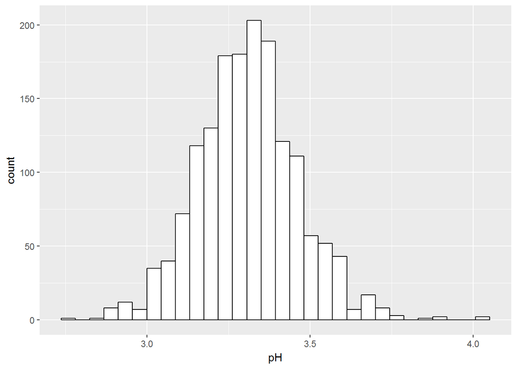

```
##    Min. 1st Qu.  Median    Mean 3rd Qu.    Max.
##   2.740   3.210   3.310   3.311   3.400   4.010
```

This looks like a normal distribution to me. With min value 2.7 and max value 4.

```
##        X          fixed.acidity    volatile.acidity  citric.acid
##  Min.   : 268.0   Min.   : 5.000   Min.   :0.2600   Min.   :0.0300
##  1st Qu.: 462.5   1st Qu.: 7.250   1st Qu.:0.3350   1st Qu.:0.3025
##  Median : 709.0   Median : 8.250   Median :0.3700   Median :0.4200
##  Mean   : 826.7   Mean   : 8.567   Mean   :0.4233   Mean   :0.3911
##  3rd Qu.:1182.5   3rd Qu.:10.225   3rd Qu.:0.4725   3rd Qu.:0.5300
##  Max.   :1550.0   Max.   :12.600   Max.   :0.8500   Max.   :0.7200
##  residual.sugar    chlorides       free.sulfur.dioxide
##  Min.   :1.400   Min.   :0.04400   Min.   : 3.00
##  1st Qu.:1.800   1st Qu.:0.06200   1st Qu.: 6.00
##  Median :2.100   Median :0.07050   Median : 7.50
##  Mean   :2.578   Mean   :0.06844   Mean   :13.28
##  3rd Qu.:2.600   3rd Qu.:0.07550   3rd Qu.:16.50
##  Max.   :6.400   Max.   :0.08600   Max.   :42.00
##  total.sulfur.dioxide    density             pH          sulphates
##  Min.   :12.00        Min.   :0.9908   Min.   :2.880   Min.   :0.6300
##  1st Qu.:16.00        1st Qu.:0.9942   1st Qu.:3.163   1st Qu.:0.6900
##  Median :21.50        Median :0.9949   Median :3.230   Median :0.7400
##  Mean   :33.44        Mean   :0.9952   Mean   :3.267   Mean   :0.7678
##  3rd Qu.:43.00        3rd Qu.:0.9972   3rd Qu.:3.350   3rd Qu.:0.8200
##  Max.   :88.00        Max.   :0.9988   Max.   :3.720   Max.   :1.1000
##     alcohol         quality
##  Min.   : 9.80   Min.   :8
##  1st Qu.:11.32   1st Qu.:8
##  Median :12.15   Median :8
##  Mean   :12.09   Mean   :8
##  3rd Qu.:12.88   3rd Qu.:8
##  Max.   :14.00   Max.   :8
```

Now I checked the most popular alcohol proof and with the highest quality which is 8. After ploting I gues that the quality doesn’t really depend purely on the alcohol concentration. The plot looks similar to uniform distribution plot.

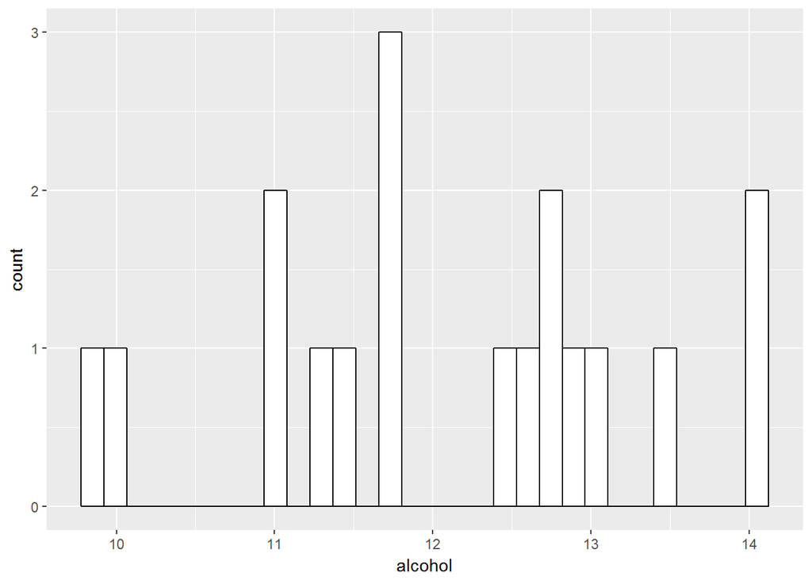

```
##    Min. 1st Qu.  Median    Mean 3rd Qu.    Max.
##    9.80   11.32   12.15   12.09   12.88   14.00
```

The highest quality wine has the minimum alcohol percentage of 9.8 and maximum of 14.

[figure not shown]

```
##    Min. 1st Qu.  Median    Mean 3rd Qu.    Max.
##    8.40   10.00   10.80   10.86   11.70   14.00
```

```
##    Min. 1st Qu.  Median    Mean 3rd Qu.    Max.
##   8.400   9.400   9.700   9.926  10.300  14.900
```

Could there be any relationship between volatile acidity and quality?

[figure not shown]

```
##    Min. 1st Qu.  Median    Mean 3rd Qu.    Max.
##  0.1200  0.3500  0.4600  0.4741  0.5800  1.0400
```

```
##    Min. 1st Qu.  Median    Mean 3rd Qu.    Max.
##  0.1800  0.4600  0.5900  0.5895  0.6800  1.5800
```

I can see that the better quality wines ten to be less acidic. I can also see that lower quality wine has an outlier which increases the x axis. Since the 3rd quartile is 0.68 and the max value is 1.58 I would asume that theres a pretty big outlier there.

# Univariate Analysis

### What is the structure of your dataset?

There are 1599 wines(observations) in the dataset, with 13 variables:

There are no ordered factor variables in this data set.

### What is/are the main feature(s) of interest in your dataset

My main interest in this data set is quality. I want to figure out what variable influance the quality of wine the most.

### What other features in the dataset do you think will help support your

investigation into your feature(s) of interest?

The other features that will help support my investigation will be alcohol percentage, acidity and pH.

### Did you create any new variables from existing variables in the dataset?

No

### Of the features you investigated, were there any unusual distributions? Did

you perform any operations on the data to tidy, adjust, or change the form of the data? If so, why did you do this?

# Bivariate Plots Section

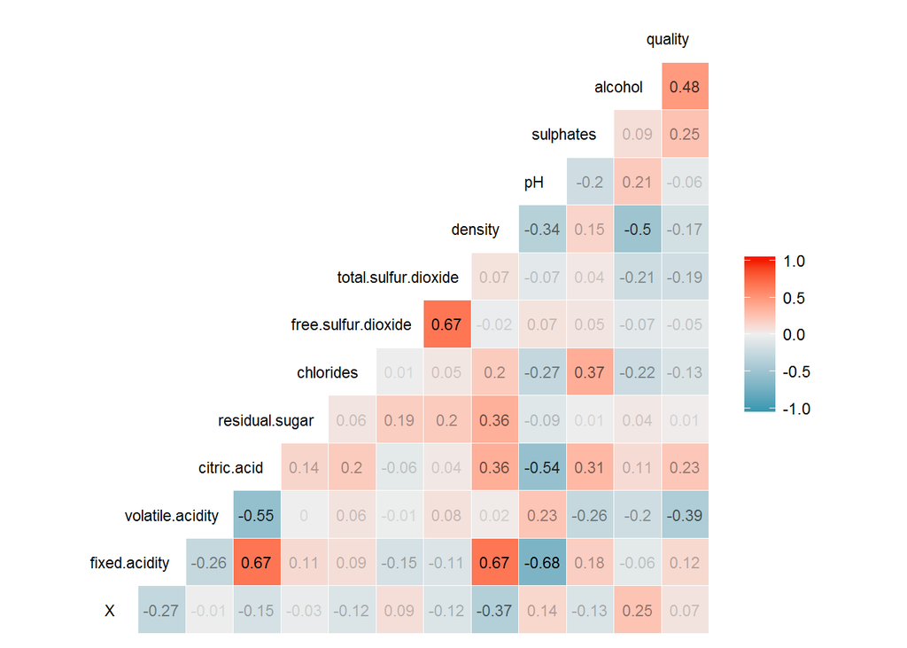

First I checked for correlations I use cor function and check correlation between each of the variables.

I can now see that the quality has the strongest correlation between these variables: volatile.acidity, sulphates and alcohol. I was right about that alcohol and volatile acidity could be the biggest factors for change in quality, i was wrong about pH though.

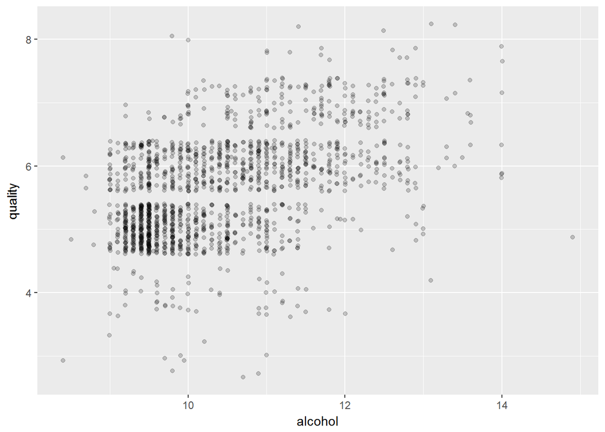

```
##     quality         alcohol
##  Min.   :3.000   Min.   : 8.40
##  1st Qu.:5.000   1st Qu.: 9.90
##  Median :6.000   Median :10.95
##  Mean   :5.737   Mean   :11.03
##  3rd Qu.:7.000   3rd Qu.:12.00
##  Max.   :8.000   Max.   :14.90
```

```
## [1] 0.4761663
```

Checked the correlation between these variables.

I used a scaterplot to see a relationship between alcohol and quality.

In this plot I can see some points that are above 8. I run the max() on quality variable to check for max value.

I get that max value for quality is 8, but my scatter plot shows some points that are above 8. Later I figured out that geom_jitter scatters the points and when running geom_point it shows the right values.

Transforming the y axis to show median and means.

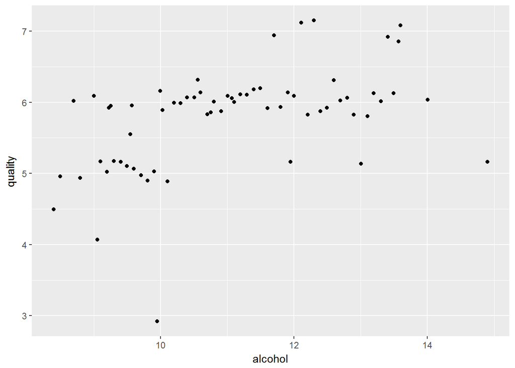

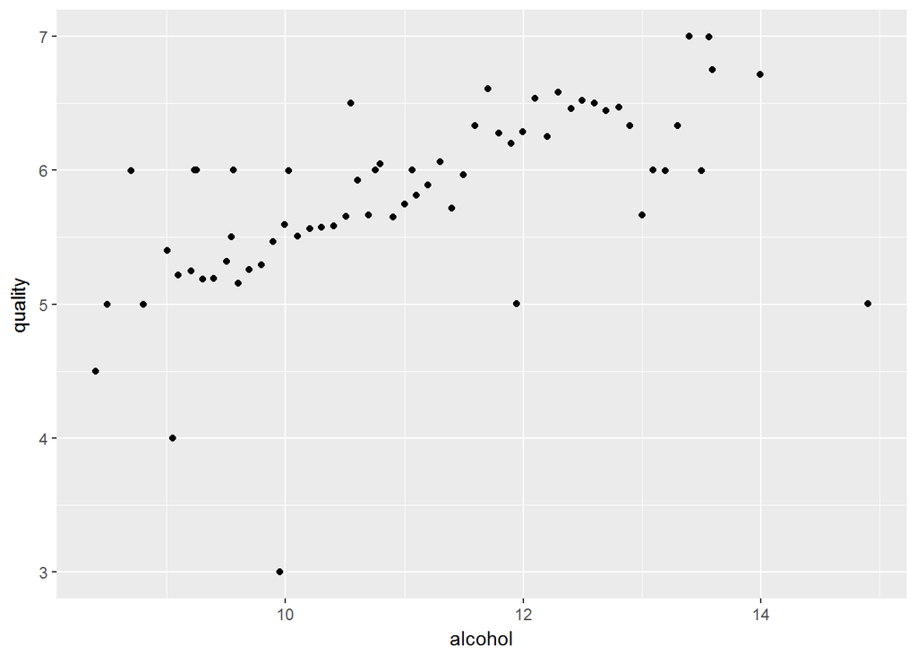

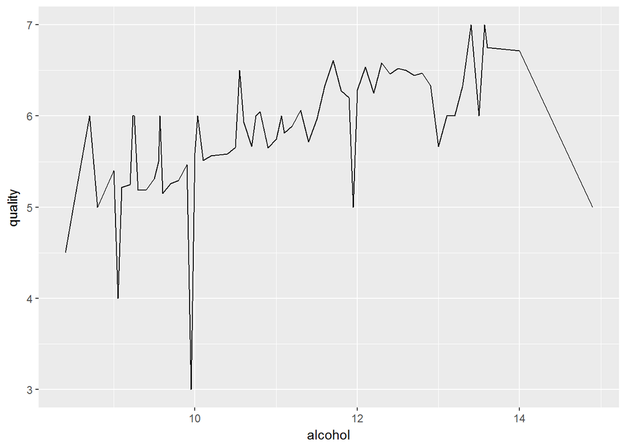

The plots show some correlation. Increasing the alcohol percentage might increase the quality. But I might be wrong.

Plotting boxplots.

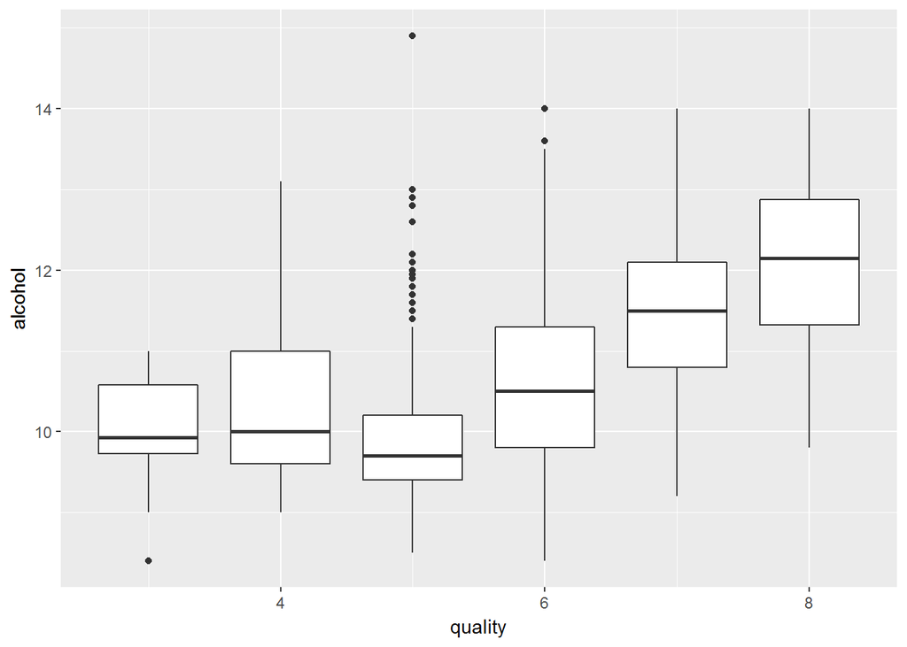

```
##     quality         alcohol
##  Min.   :3.000   Min.   : 8.40
##  1st Qu.:5.000   1st Qu.: 9.90
##  Median :6.000   Median :10.95
##  Mean   :5.737   Mean   :11.03
##  3rd Qu.:7.000   3rd Qu.:12.00
##  Max.   :8.000   Max.   :14.90
```

```
## [1] 0.4761663
```

This boxplot also shows that wines with higher alcohol percentage is rated better in quality.

Checking quality by volatile.acidity.

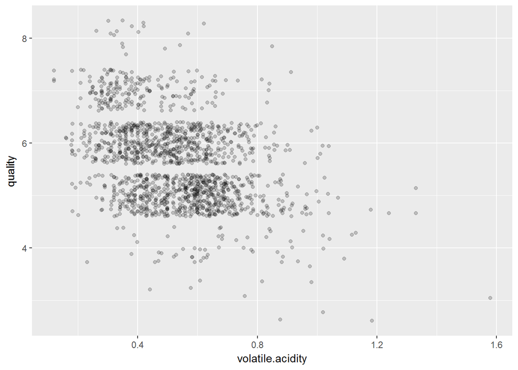

```
##     quality      volatile.acidity
##  Min.   :3.000   Min.   :0.1200
##  1st Qu.:5.000   1st Qu.:0.4000
##  Median :5.000   Median :0.6075
##  Mean   :5.552   Mean   :0.6064
##  3rd Qu.:6.000   3rd Qu.:0.7800
##  Max.   :8.000   Max.   :1.5800
```

```
## [1] -0.3905578
```

The scatterplot seems a bit linear. I want to scatter it a bit more to see the trends, so I will calculate and apply means to Y axis.

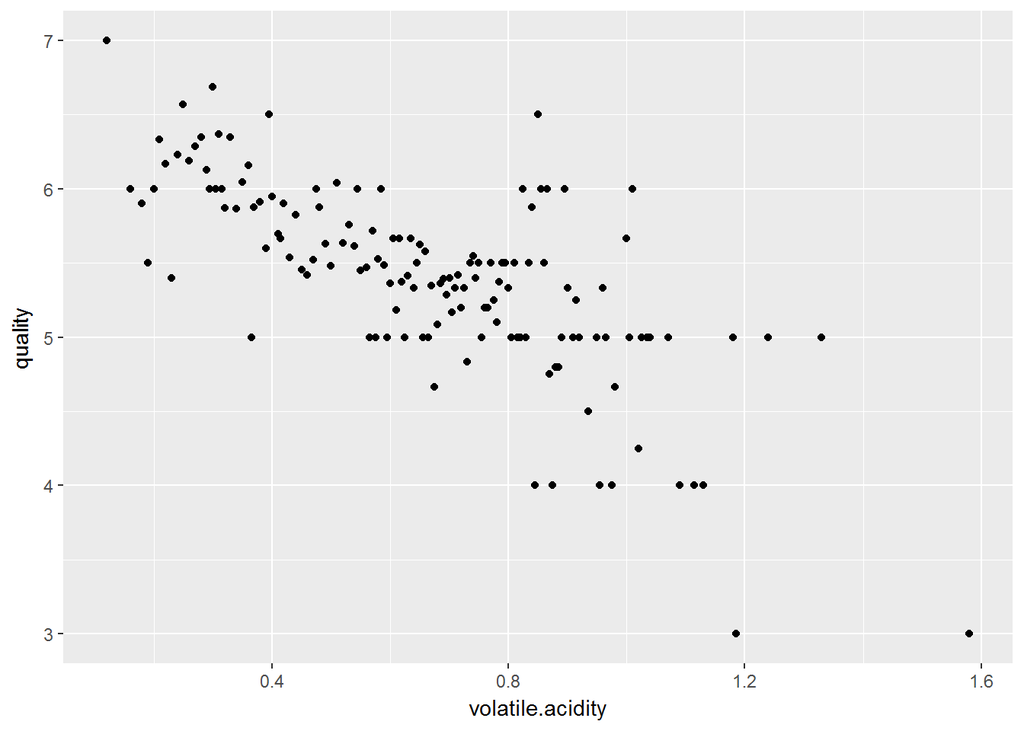

I can see a trend that as the volatile acidity increases, the quality decreases.

Plotting boxplots.

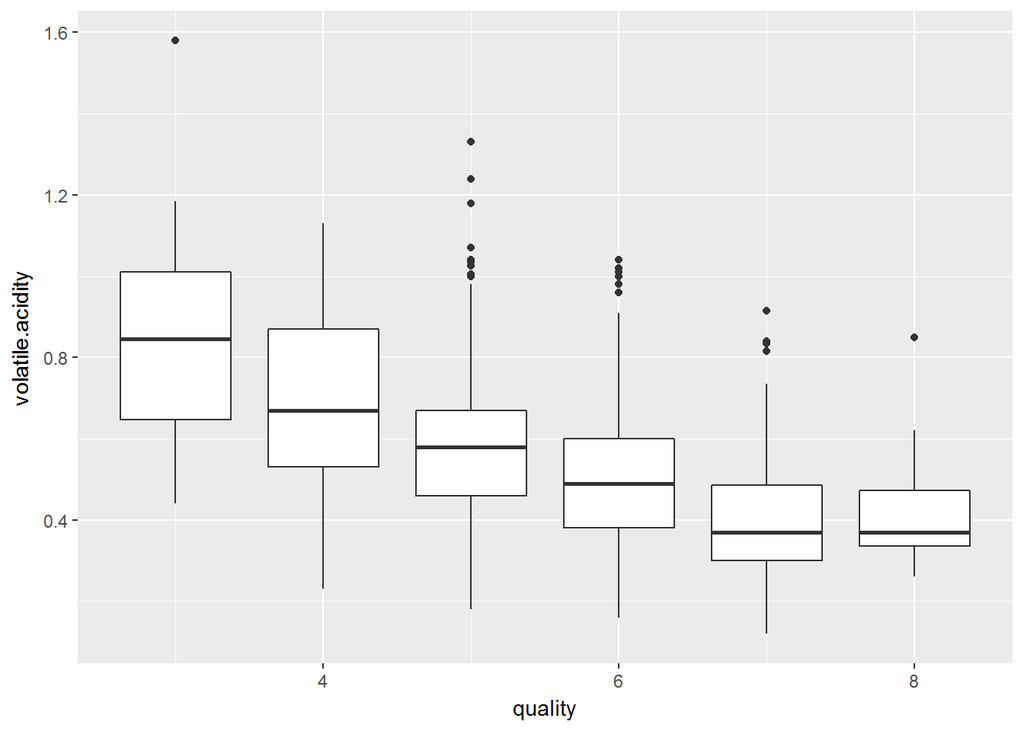

```
##     quality      volatile.acidity
##  Min.   :3.000   Min.   :0.1200
##  1st Qu.:5.000   1st Qu.:0.4000
##  Median :5.000   Median :0.6075
##  Mean   :5.552   Mean   :0.6064
##  3rd Qu.:6.000   3rd Qu.:0.7800
##  Max.   :8.000   Max.   :1.5800
```

```
## [1] -0.3905578
```

From these boxplots I can see the trend that the quality decreases if acidity increases. I can see some outliers here which might increase the means. I will use summary to check for the max and mean values.

I can see some outliers, so i created a plot without them.

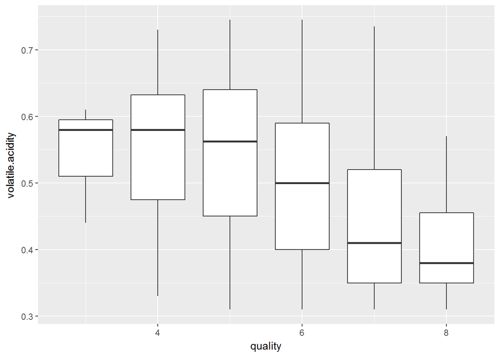

```
##    Min. 1st Qu.  Median    Mean 3rd Qu.    Max.
##  0.3100  0.4188  0.5275  0.5275  0.6362  0.7450
```

```
## [1] -0.3905578
```

I added outlier.shape = NA to remove outlier shapes from the plot and then set the both bottom and upper limits of y axis. This plot also shows this trend that the higher the acidity - the lower is quality. I summarised only the values without outliers using quantile function. I get min value of 0.31 and max value of 0.75

# Bivariate Analysis

### Talk about some of the relationships you observed in this part of the

investigation. How did the feature(s) of interest vary with other features in the dataset?

I checked my feature of interest (quality) against 2 variables: volatile.acidity and alcohol. The relationship with alcohol was that I saw a trend that higher alcohol percentage means higher quality. For volatile acidity I saw that high acidity means lower quality.

### Did you observe any interesting relationships between the other features

(not the main feature(s) of interest)?

I only observed the relationships to quality, so no i did not observe interesting relationships between other features.

### What was the strongest relationship you found?

In my main feature of interest I found out that quality has a strong relationship with alcohol percentage. As the alchohol percentage increases, so does quality of the wine. The correlation coeficent between these 2 variables is 0.48. The other strong relationship I found was between acids and pH which is not surprising at all.

# Multivariate Plots Section

## 14. Creating a new summary

```
##  volatile.acidity    quality            pH          alcohol
##  Min.   :0.1200   Min.   :3.000   Min.   :2.74   Min.   : 8.40
##  1st Qu.:0.3900   1st Qu.:5.000   1st Qu.:3.21   1st Qu.: 9.50
##  Median :0.5200   Median :6.000   Median :3.31   Median :10.20
##  Mean   :0.5295   Mean   :5.625   Mean   :3.31   Mean   :10.43
##  3rd Qu.:0.6400   3rd Qu.:6.000   3rd Qu.:3.40   3rd Qu.:11.10
##  Max.   :1.5800   Max.   :8.000   Max.   :4.01   Max.   :14.90
```

I created a group of variables to easier summarise the data that I want.

## 14. Checking various plots.

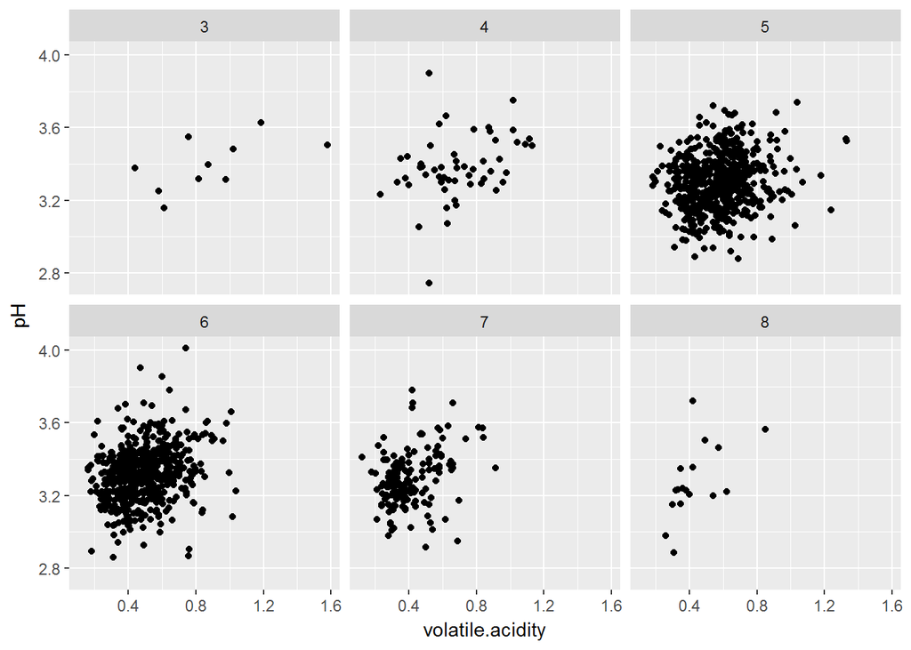

```
##  volatile.acidity    quality            pH
##  Min.   :0.1200   Min.   :3.000   Min.   :2.74
##  1st Qu.:0.3900   1st Qu.:5.000   1st Qu.:3.21
##  Median :0.5200   Median :6.000   Median :3.31
##  Mean   :0.5316   Mean   :5.618   Mean   :3.31
##  3rd Qu.:0.6412   3rd Qu.:6.000   3rd Qu.:3.40
##  Max.   :1.5800   Max.   :8.000   Max.   :4.01
```

```
## [1] 0.2349373
```

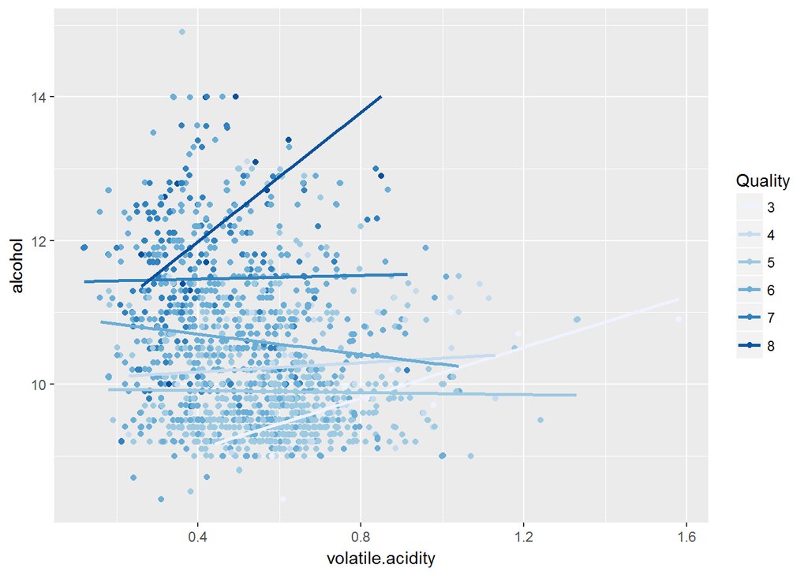

```
##  volatile.acidity    quality         alcohol
##  Min.   :0.1200   Min.   :3.000   Min.   : 8.4
##  1st Qu.:0.3900   1st Qu.:5.000   1st Qu.: 9.6
##  Median :0.5200   Median :6.000   Median :10.3
##  Mean   :0.5319   Mean   :5.657   Mean   :10.5
##  3rd Qu.:0.6475   3rd Qu.:6.000   3rd Qu.:11.2
##  Max.   :1.5800   Max.   :8.000   Max.   :14.9
```

```
## [1] -0.202288
```

From this plot I can see that the highest quality wines tend to heave more alcohol in it and it also is from low to medium acidity. Lower quality wines usualy have a wider range of acidity maxing at 1.6, it also tend to have less alcohol in it. The weird thing is that as the best quality has the most alcohol, lowering the quality drasticaly reduces the alcohol percentage, and then at the lowest point in quality, the alcohol percentage drasticaly increases.

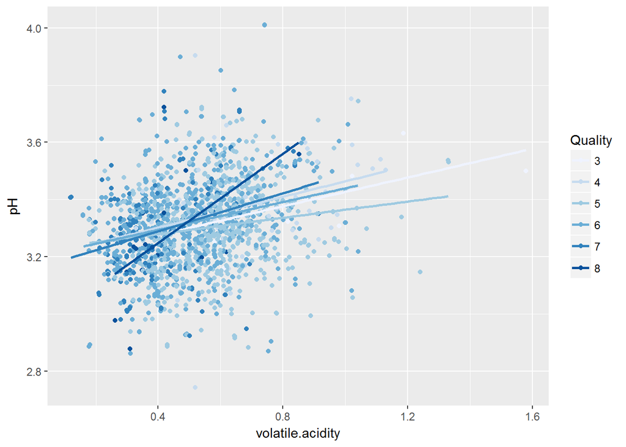

```
##  volatile.acidity    quality            pH
##  Min.   :0.1200   Min.   :3.000   Min.   :2.74
##  1st Qu.:0.3900   1st Qu.:5.000   1st Qu.:3.21
##  Median :0.5200   Median :6.000   Median :3.31
##  Mean   :0.5316   Mean   :5.618   Mean   :3.31
##  3rd Qu.:0.6412   3rd Qu.:6.000   3rd Qu.:3.40
##  Max.   :1.5800   Max.   :8.000   Max.   :4.01
```

```
## [1] 0.2349373
```

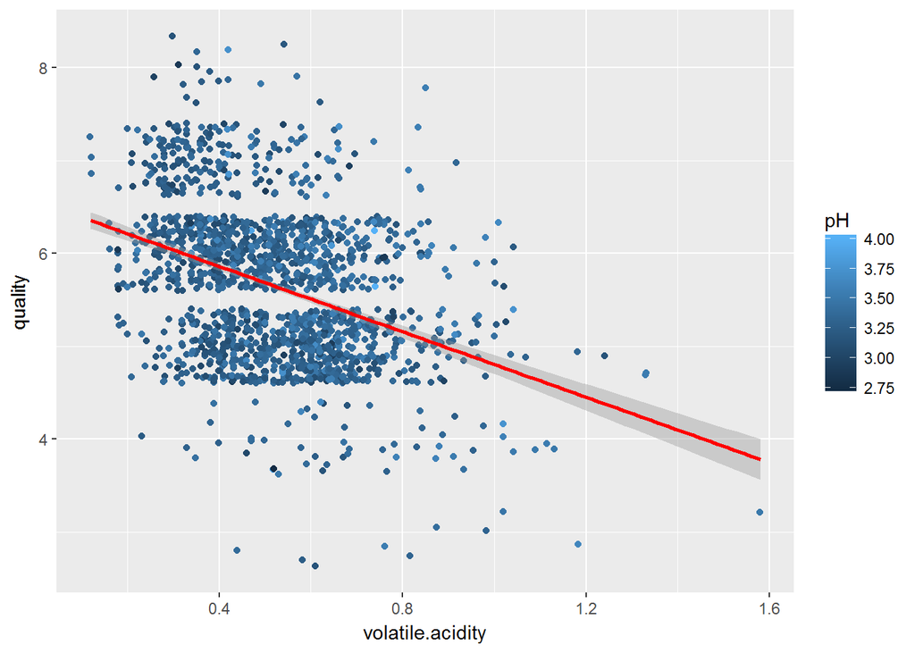

I can see that the higher pH levels might be lowering the quality, maybe because high pH means more acidity.

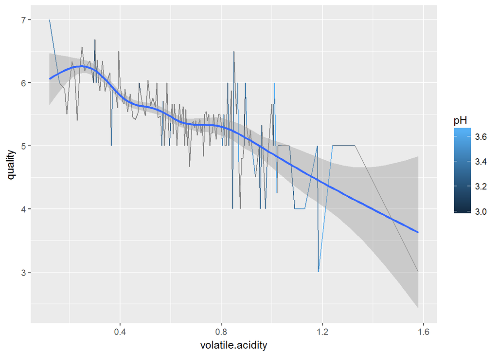

```
##  volatile.acidity    quality            pH
##  Min.   :0.1200   Min.   :3.000   Min.   :2.74
##  1st Qu.:0.3900   1st Qu.:5.000   1st Qu.:3.21
##  Median :0.5200   Median :6.000   Median :3.31
##  Mean   :0.5316   Mean   :5.618   Mean   :3.31
##  3rd Qu.:0.6412   3rd Qu.:6.000   3rd Qu.:3.40
##  Max.   :1.5800   Max.   :8.000   Max.   :4.01
```

```
## [1] -0.3905578
```

This further tells me that there is correlation between quality and volatile acidity.

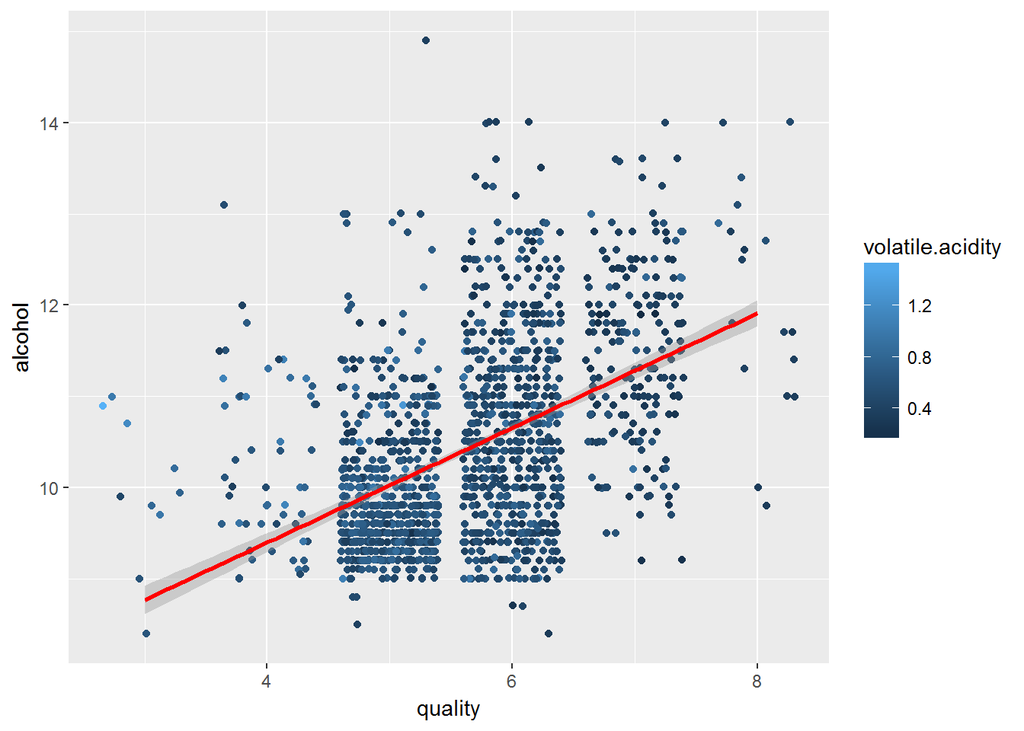

```
##  volatile.acidity    quality         alcohol
##  Min.   :0.1200   Min.   :3.000   Min.   : 8.4
##  1st Qu.:0.3900   1st Qu.:5.000   1st Qu.: 9.6
##  Median :0.5200   Median :6.000   Median :10.3
##  Mean   :0.5319   Mean   :5.657   Mean   :10.5
##  3rd Qu.:0.6475   3rd Qu.:6.000   3rd Qu.:11.2
##  Max.   :1.5800   Max.   :8.000   Max.   :14.9
```

```
## [1] -0.3905578
```

I can clearly see that increasing alcohol percentage we would increase quality, but I see no big trends petween volatile.acidity and these 2 variables. Maybe I can see something if I compare alcohol, quality and pH?

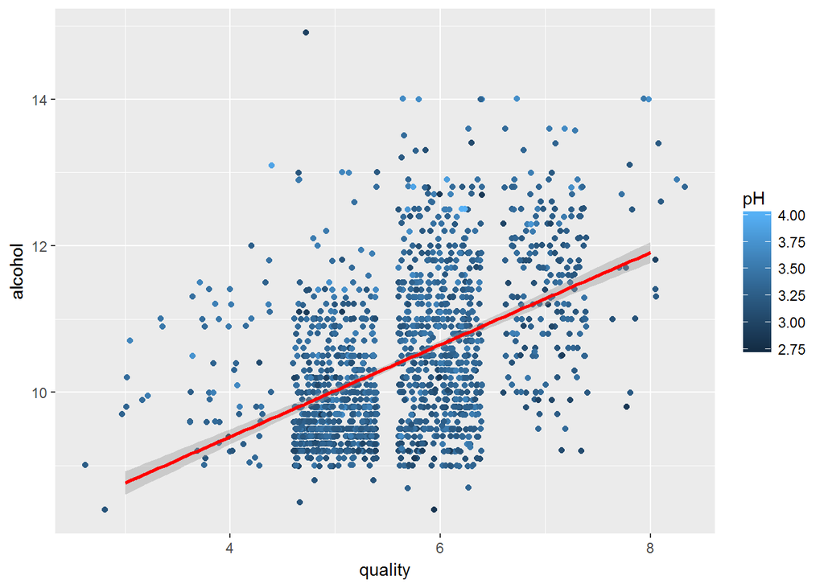

```
##     alcohol         quality           pH
##  Min.   : 8.40   Min.   :3.00   Min.   :2.740
##  1st Qu.: 9.60   1st Qu.:5.00   1st Qu.:3.210
##  Median :10.35   Median :6.00   Median :3.310
##  Mean   :10.54   Mean   :5.68   Mean   :3.314
##  3rd Qu.:11.30   3rd Qu.:6.00   3rd Qu.:3.410
##  Max.   :14.90   Max.   :8.00   Max.   :4.010
```

```
## [1] 0.4761663
```

I can see a small correlation between pH and alcohol, since lower pH wines tend to sit in the bottom of the plot, and that means lower alcohol could mean lower pH value.

# Multivariate Analysis

### Talk about some of the relationships you observed in this part of the

investigation. Were there features that strengthened each other in terms of looking at your feature(s) of interest?

I was not surprised with the outcomes of my plots. I suspected that volatile acidity lowers the quality and higher alcohol concentration might increase the quality. Checking the correlation between these variables showed me that they are correlated, and the plots helped me to be sure about that.

### Were there any interesting or surprising interactions between features?

Before my analysis I was really thinking that lower alcohol percentage would mean better quality, but that proved me wrong. I was also thinking that pH and volatile acidity should have very similar results for highest quality wines, but it seems that its not. Another interesting thing was that the lower quality wines has less and less alcohol in it, bus as the quality reaches lowest point, the alcohol percentage drasticaly increases.

### OPTIONAL: Did you create any models with your dataset? Discuss the strengths and limitations of your model.

No.

# Final Plots and Summary

### Plot One

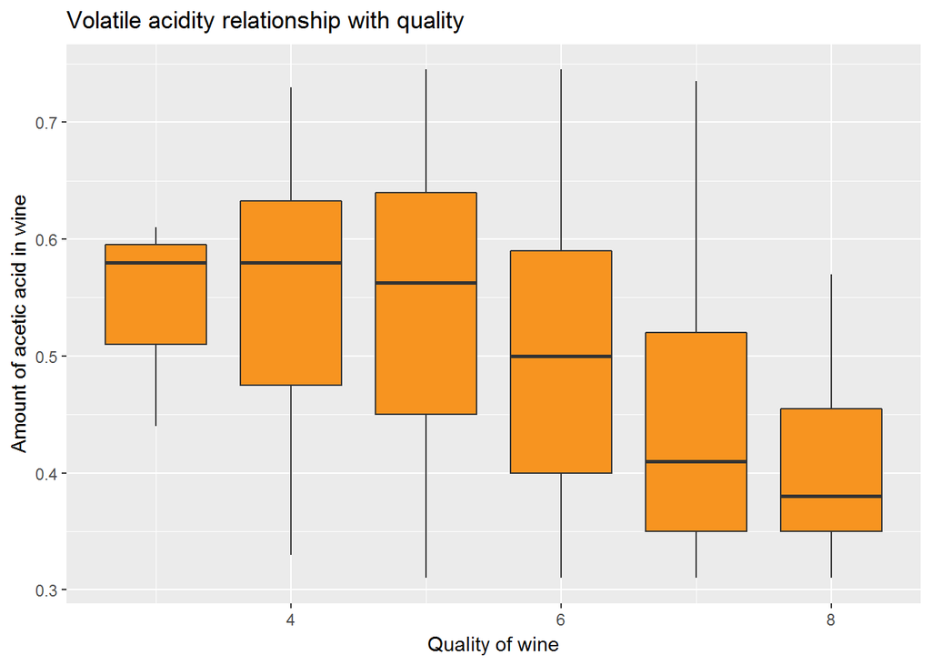

### Description One

I wanted to see what is the relationship between acidity and quality. I was hoping for this relationship to be somehow neutral. To see the relationship I plotted a boxplot. The boxplot had many outliers and was interfering with my means, so I had to remove the outliers to see the real relationship. After plotting the final boxplot I see clear tendency that increasing acidity - decreases the quality.

### Plot Two

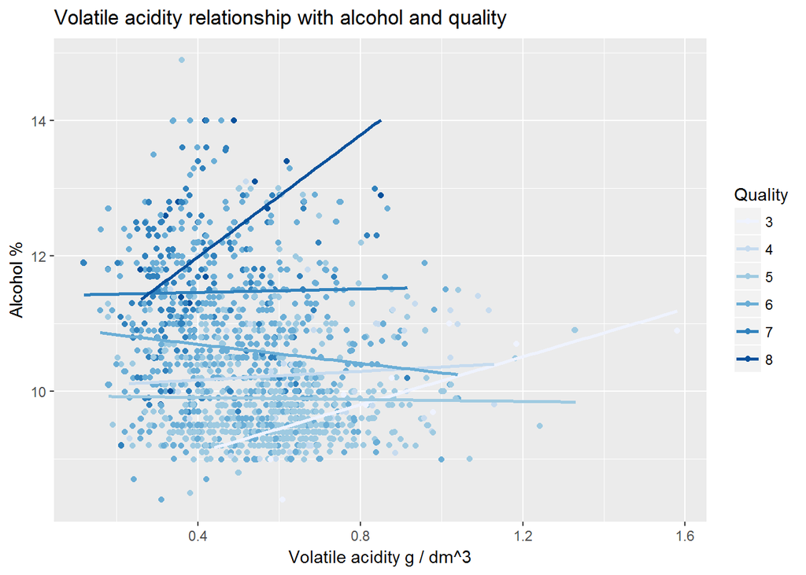

### Plot Three

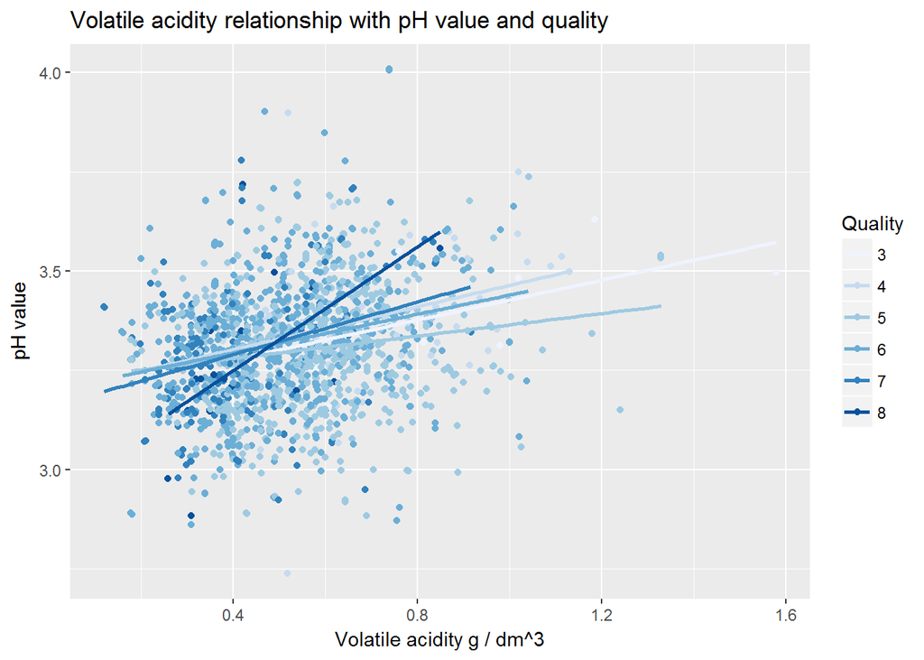

### Description Three

# Reflection

The Red Wine Quality dataset includes 1599 observations with 13 variables. As I was exploring the data set I found that the most interesting variable for me is quality, which I based my project on. I Tried to check pH, alcohol, acidity variables against quality to see for some interesting correlations.

I strugled with some of the outliers screwing my boxplots, but later I found out how to set the limits on Y axis using quantile functiont by removing top 10% and bottom 10% of data from the plot. Another difficulty was that the dataframe is tiny compared to others, and 1599 observations doesn’t make beutifull scatterplots. Besides these problems all went well and I noticed that the biggest correlations between quality was alcohol and acidity. Higher alcohol improves the quality while acidity decreases it.

For better analysis in the future I would try to test all of the variables and maybe join the white wine and red wine datasets to see evem bigger trends.